# Project 2: Tim’s stab at it

# Sort-of-bonus: resampling

**Click for sample_umis() function code**

```r
# adapted from a SingleCellExperiment-centric method for CITEseq
sample_umis <- function(umis, meta, block, ideal=300, verbose=TRUE, justnames=FALSE) {

  stopifnot(nrow(meta) == ncol(umis))
  stopifnot(length(block) == nrow(meta))

  pops <- sort(table(block))
  samplesets <- split(seq_len(nrow(meta)), block)

  keep <- integer()
  for (set in names(samplesets)) {
    sset <- samplesets[[set]]
    cells <- length(sset)
    if (cells <= ideal) {
      pct <- 100
      keep <- c(keep, sset)
      if (verbose) message("Kept ",cells," cells (",pct,"%) of type ",set,".")
    } else {
      kept <- sample(sset, size=ideal)
      pct <- round((ideal / cells) * 100)
      keep <- c(keep, kept)
      if (verbose) message("Kept ",ideal," cells (",pct,"%) of type ",set,".")
    }
  }

  pct <- round((length(keep) / ncol(umis)) * 100, 1)
  if (verbose) {
    message("Kept ", length(keep), " (", pct, "%) of ", ncol(umis),
            " cells in ", length(samplesets), " blocks.")
  }

  if (justnames) return(keep)
  else return(umis[, keep])

}
```

Let’s suppose we decided that we didn’t care which mixture the cells came from, and we just wanted to calibrate our coefficient estimates for each prep method. Recall the `replicate` loop earlier for estimating sparsity. If we take, say, 200 samples of 200 cells per method, what do our estimates (i.e., no intercept, purely marginal) look like? The function above works just fine on a tidysce, and since we are not fitting an intercept, we can perform a simplified version of logistic regression simply by computing marginals.

```r
# simple classifier: is it suspect? then it's a failure
performance_by_method <- function(subsample, atibble) {

  subs <- mutate(slice(atibble, subsample), # i.e., tbl %>% slice %>% mutate
                 result=if_else(mixlabel == "suspect", "failure", "success"))
  tbl <- table(select(subs, method, result)) # force of habit
  probs <- as(sweep(tbl, 1, rowSums(tbl), `/`), "matrix")
  rownames(probs) <- NULL # avoid hassles when stacking
  tibble(cbind(method=rownames(tbl), data.frame(probs)))

}

# a simple bootstrap (for efficiency, we don't bother grabbing the UMIs at all)
# per the above (and to make computing intervals easier), we'll use 200x200
subsamples <- replicate(n=200, simplify=FALSE, # to make it easier to iterate
                        sample_umis(tidybarnyard, as_tibble(tidybarnyard),
                                    tidybarnyard$method, ideal=200,
                                    justnames=TRUE, verbose=FALSE))
names(subsamples) <- paste0("run", seq_along(subsamples))

# purrr::map maps a function over a list
library(purrr)

# evaluate performance with 200 bootstrap samples of (ideally) 200 cells/method
# (i.e. subsamples <- replicate(n=200, sample_umis(..., ideal=200, ...)), above)
runs <- purrr::map(subsamples, performance_by_method, atibble=barnyardtibble)

# for plotting, stack them row-by-row
results <- bind_rows(runs)
```

Per usual, it helps to plot the results.

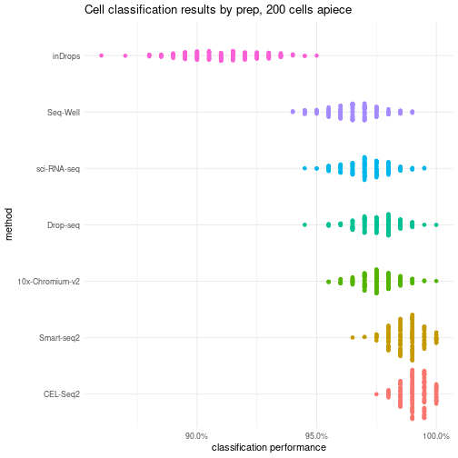

```r
# fire up geom_sina because it rules:
library(ggforce)

# for better resolution, you could resample batches of 500, 1000, ...
results %>%
  mutate(method = fct_reorder(method, desc(success), .fun='median')) %>%
  ggplot(aes(method, success, color=method)) +
            scale_y_continuous(labels = scales::label_percent()) +
            ylab("classification performance") +
            geom_sina(show.legend=FALSE) +
            coord_flip() +
            theme_minimal() +
            ggtitle("Cell classification results by prep, 200 cells apiece")
```

*Question:* What does `fct_reorder` (from the `forcats` package) do above?

You might conclude that we could directly compute confidence intervals from the above results. You would be correct. Let’s do this tidily:

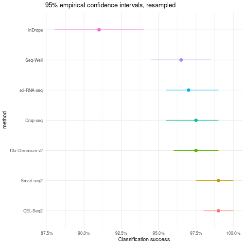

```r
# ground rules
CI <- 0.95                                      # must be between 0 and 1
lower <- (1 - CI) / 2                           # defined by the value of CI
upper <- 1 - lower                              # defined by the value of lower
middle <- (lower + upper) / 2                   # this is a tautology and a test
plot_title <- paste0(CI * 100, "% empirical confidence intervals, resampled")

# grouping
results %>%
  group_by(method) %>%                          # create a grouped data frame
  summarize(lower=quantile(success, lower),     # lower limit of the CI
            middle=quantile(success, middle),   # middle (== median)
            upper=quantile(success, upper)) ->  # upper limit of the CI
    CIs                                         # assign to a new tibble, "CIs"

# reorder to plot
library(forcats)
CIs %>%
  mutate(method = fct_reorder(method, desc(middle))) %>%
  ggplot(aes(x=method, ymin=lower, y=middle, ymax=upper, color=method)) +
  scale_y_continuous(labels = scales::label_percent()) +
  geom_pointrange(show.legend=FALSE) +
  ylab("Classification success") +
  coord_flip() +
  theme_minimal() +
  ggtitle(plot_title)
```

*Question (not required)*: Can you overlay the two summaries above? (I can’t.)

*Question (not required)*: Is it feasible to block on experiment x method?

*Question (not required)*: How could you structure a scheme for the above?

(Note that I might ask you to do something very much like this in project 3…)

# An equivalence between hypothesis tests and confidence intervals

Perhaps you’ve previously been told that it is not possible to exclude the possibility that two groups (or groups of samples) are equivalent at the 5% alpha level if their 95% confidence intervals overlap. This is in fact the case, since inverting a test at a given alpha is equivalent to computing a (1-alpha)% confidence interval. Congratulations, you just computed all marginal comparisons for these methods at a significance level of 0.05.

*Question:* What happens if you take bigger samples, or more of them, or both?

Suppose we went back to the original dataset (or, for the sake of argument, a larger dataset) and resampled the hell out of it. At some point, do you suppose you could choose a single “best” library prep method with 95% confidence (i.e., a family-wise error rate of 0.05, or 5%)? This is roughly equivalent to a Holm (or, if you can’t count, Bonferroni) correction a the same alpha level.

*Question:* Did you have to make any assumptions to do this? Which ones?

If you think this is a discussion about statistical power and significance, you’re right. If you think that resampling is always the answer…

*Question:* Is there a limit to how tight your intervals can be from resampling?

(Hint: Yes. Consider the number of possible unique outcomes and permutations. Note that if we want exact CIs, we need to avoid double-counting the results.)

*Question:* Can you come up with a resampling based scheme that is exhaustive, i.e., it samples every possible permutation of draws from the data, no more, no less? Does this scheme change if you block on multiple variables or groupings?

(Hint: Look up “leave-one-out cross-validation”.)

# Tests and other impedimentia

You can also ask more interesting questions, like how many times a given method ends up with the best performance out of the lot in each sampling run. This is perhaps a better representation of what to expect if you applied a prep, or a labeling scheme, or a test across multiple smaller experiments. Like, say, if your instructor asked you to determine a sample size at which you had an 80% chance of successfully discriminating some rare cell type from others, and oh by the way, you need to choose between protocols that cost different amounts per cell. And perhaps you wanted a way to look at different classifiers as well as different prep or sort methods for your Extremely Important Rare Cell Type. Because as you can probably guess from the above, you’re not limited to just comparing methods, or even using the same sample size per block, to do this.

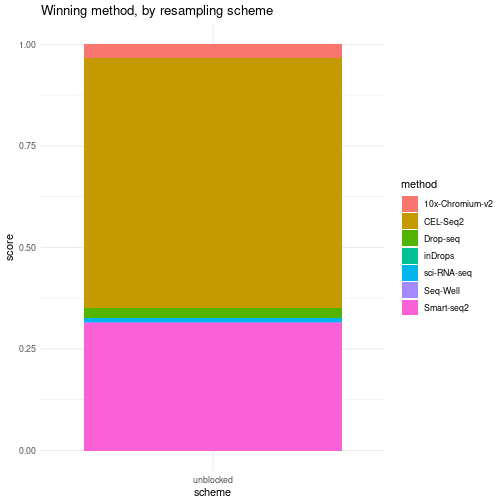

```r
# assign 1 point to the winner, 0 otherwise
# in the case of ties, split the point N ways
score_methods <- function(run) {

  top <- max(run$success)
  run$points <- as.numeric(run$success == top)
  score <- run$points / sum(run$points)
  names(score) <- run$method
  return(score)

}

# tally up the scores
runs %>%
  purrr::map(score_methods) %>%  # map the function score_methods onto each run
  bind_rows() %>%                # bind the results as rows of a tibble
  colSums -> scores              # compute the column sums and assign to scores

# tibble-ify for plotting
outcome <- tibble(method=names(scores),
                  score=scores,
                  scheme="unblocked")

# plot it
outcome %>% ggplot(aes(x=scheme, y=score, fill=method)) +
            geom_col(position="fill") +
            theme_minimal() +
            ggtitle("Winning method, by resampling scheme")
```

So that’s why I left the resampling in. Because it is in fact the state of the art for single-cell experimental design evaluation in the context of power and efficiency. (You want the best balance of false positives and false negatives possible for your experiment, and can choose whatever tools you wish to achieve that balance; this is the point of a well executed experimental design.) You will note that nowhere in the above resampling schemes have we assumed much of anything other than that a mixture model is usually optimal for cell labeling (because it is, in the general case; though you should feel free to investigate whether something else might work better for any specific experiment of yours).

# Philosophical bloviation

You might begin to think that experimental design is about navigating tradeoffs. One tradeoff that most people (including myself) are rarely equipped to navigate by intuition is what test or method to use. So don’t: let the data tell you. And absolutely do include some positive and negative controls in your experiments, whether they are *in vitro*, *in vivo*, or *in silico*. This is particularly important when [evaluating new and/or fashionable techniques](https://www.biorxiv.org/content/10.1101/2021.11.15.468733v1.full).

*Question:* Can you think of a way to include some negative controls in this experiment? We know that there are empty droplets in many methods, and we know that doublets are not uncommon in droplet-based methods. Suppose you had access to an independent label or labels on each cell, as you might find in a [CITE-seq experiment](https://www.nature.com/articles/s41592-020-01050-x/figures/1). If you haven’t bumped into one before, here’s roughly how it works:

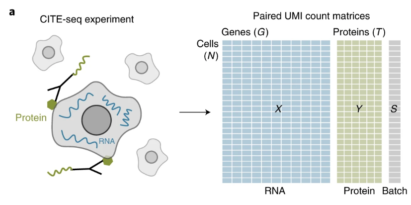

a CITE-seq experiment

Specifically, suppose you coded up the human and mouse cells (or the cell types you actually cared about) with batch (HTO, hash-tag oligo) labels, like in the ‘S’ column of the matrix above. (Think of it as a great big tibble, and think of the pieces of the big matrix as alternative assays.) Further, the protein tags could help quite a bit if you think there really are expressed differences within the usual cell subtypes.

*Question*: Can you use this to devise positive and negative controls in a way that makes biological sense?

Congratulations, now you’re even a little beyond the state of the published art. Apologies if Scott or I gave you the impression that [most published research is false](https://journals.plos.org/plosmedicine/article?id=10.1371/journal.pmed.0020124). That might be discouraging, and we wouldn’t want to suggest that there is [anything wrong with academic research](https://royalsocietypublishing.org/doi/10.1098/rsos.160384)!